# Simulation Scenario B

Table 1.2 shows the computed values of $\lambda_j$ for our hazard function. Figure 1.2 compares the simulated cumulative survival probabilities from age 50 years based on these $\lambda_j$, i.e., the probability of surviving to each age conditional on survival to age 50, with cumulative survival probabilites calculated from the Netherlands life tables. Figure 1.3 compares the simulated mortality hazard ratios from ages 50+ to those calculated from life tables. Both the survival probabilities calculated from simulated data and the modeled mortality hazard ratios were averaged over 500 iterations of sample generation. The average of the mortality hazard ratios was computed by first taking the mean of the observed age-specific ln(mortality HR) across the 500 simulated samples and then exponentiating. Average cumulative mortality = 93.1% across the 500 simulated samples.

Table 1.2: Baseline hazard for females in each 5-year age band

|  | Age [50-55) | [55-60) | [60-65) | [65-70) | [70-75) | [75-80) | [80-85) | [85-90) | [90-95) |
| --- | --- | --- | --- | --- | --- | --- | --- | --- | --- |
| Lambda | 0.006 | 0.009 | 0.016 | 0.026 | 0.044 | 0.075 | 0.133 | 0.248 | 0.495 |

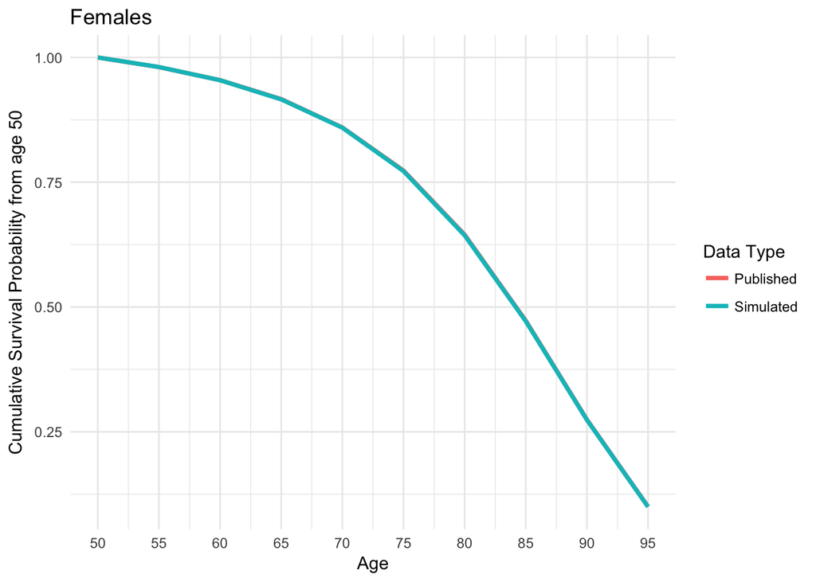

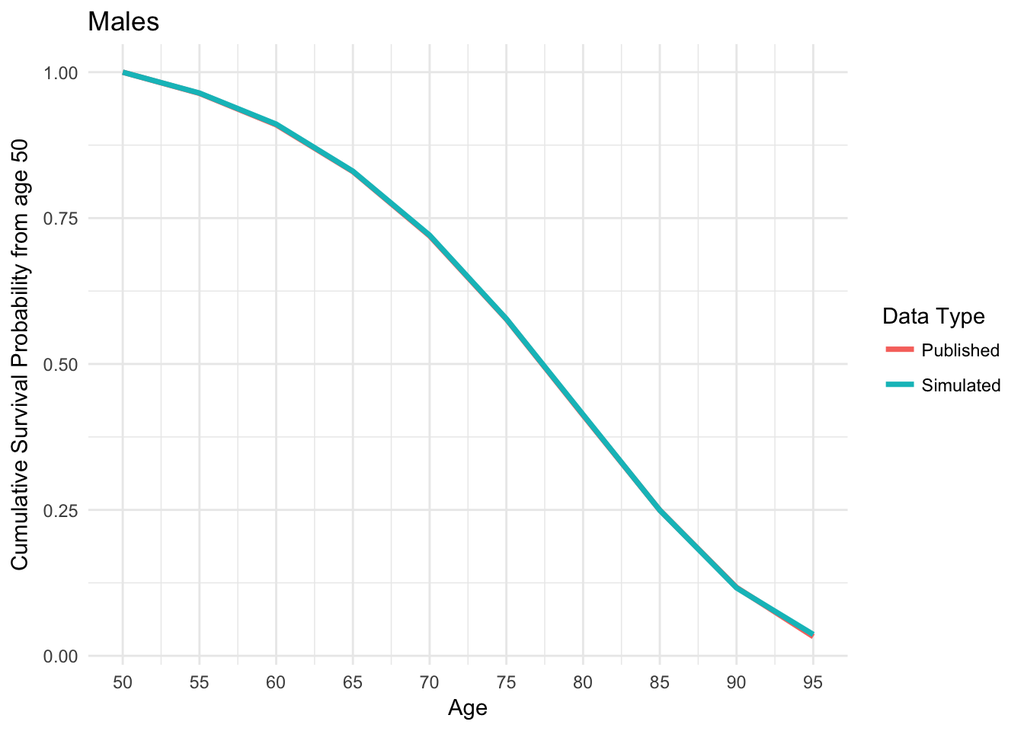

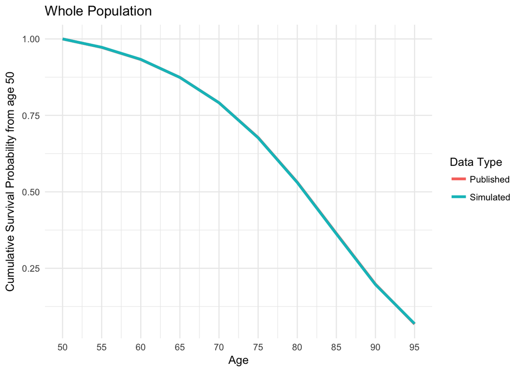

Figure 1.2: Average simulated cumulative survival probabilites from age 50 years across 500 iterations of sample generation

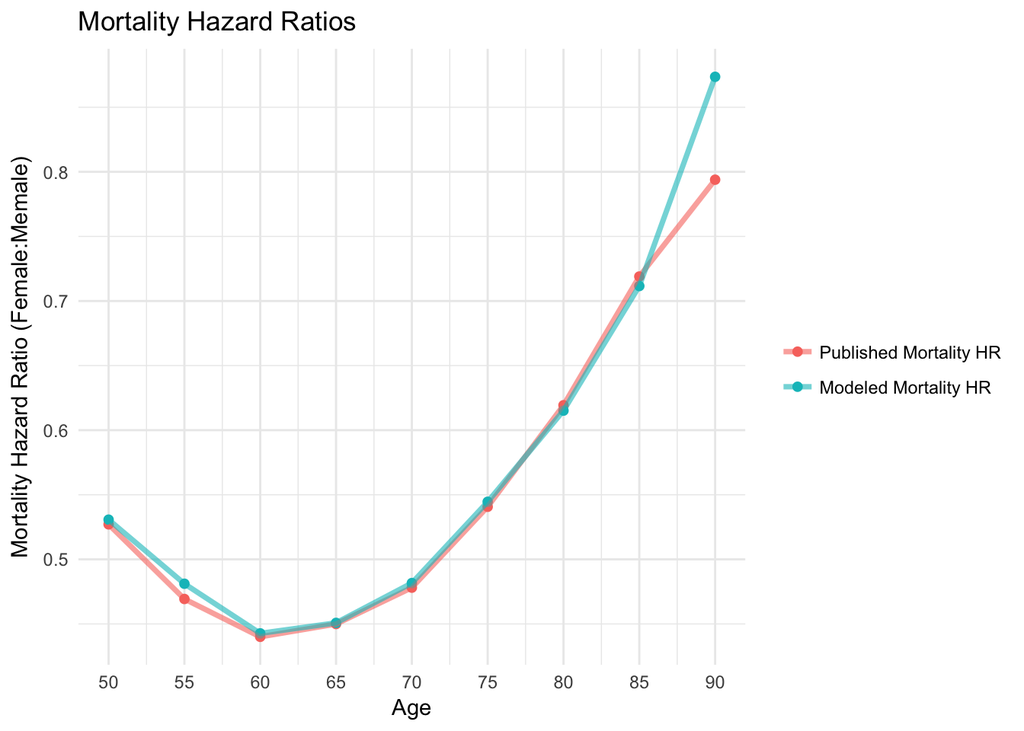

Figure 1.3: Average simulated mortality hazard ratios for age 50+ across 500 simulation runs. Ages on the x-axis represent the age at the start of interval, i.e. 50 represents the mortality HR for the interval [50, 55).

## 1.2 Dementia

$$\begin{equation}
C_{ij}(t) = \beta_{00} + \zeta_{0i} + \beta_{01}\text{sex}_i + \beta_{02}\text{age0_c50}_{i} + \beta_{03}U_i + \varepsilon_{ij} + (\text{slope}_{ij} + \zeta_{1i} + \beta_{11}\text{sex}_i + \beta_{12}\text{age0_c50} + \beta_{13}U_i)t,
\tag{1.2}
\end{equation}$$

where $\text{age0_c50}_i$ is person $i$’s baseline age centered at age 50 (0 for everyone since everyone is age 50 at the start of this hypothetical study) and where $U_i \sim N(0,1)$. Here, $\varepsilon_{ij}$ represents unexplained variation in $C_{ij}$ where $\varepsilon_{ij} \sim N(0, \sigma^2_{\varepsilon})$ and $\text{cov}(\varepsilon_{i, j}, \varepsilon_{i, k}) = \rho_{\varepsilon}^{|j - h|}\sigma^2_{\varepsilon_{ij}}$, where $j$ and $k$ represent time intervals. This structure creates a within-person autoregressive model where the variance of $\varepsilon_{ij}$ is constant across waves.

If an individual’s value of cognitive function fell below the age bin-specific dementia cut point, we solved Equation (1.3) for $t$ to get their time to dementia within that age bin. The age at which an individual is diagnosed with dementia is calculated as their age at the start of the interval plus their time to dementia within that interval.

$$\begin{equation}
C_{ij} = \text{slope}_{ij}t + C_{i,j-1}
\tag{1.3}
\end{equation}$$

Table 1.3: Dementia cut points and associated percentiles. The percentile is the proportion of susceptible that will be diagnosed with dementia.

|  | Age <50 | [50, 55) | [55-60) | [60-65) | [65-70) | [70-75) | [75-80) | [80-85) | [85-90) | [90-95) |
| --- | --- | --- | --- | --- | --- | --- | --- | --- | --- | --- |
| Dementia Cutoff | -6.4 | -6.4 | -6.400 | -6.400 | -6.400 | -6.400 | -6.400 | -6.40 | -6.400 | -6.400 |
| Percentile | 0.0 | 0.0 | 0.003 | 0.017 | 0.053 | 0.104 | 0.182 | 0.28 | 0.427 | 0.608 |

Average dementia incidence rates per 1000 person years across 500 simulated samples are displayed in Table 1.4. The dementia incidence rates from the EURODEM study, used as reference, are displayed in the first line of the table. The average dementia hazard ratios across 500 simulated scenarios are displayed in Table 1.5, and the average incidence rate ratios are displayed in Table 1.6. In both cases, ratios are presented as female:male.

Table 1.4: Dementia incidence rates. Source: Gender differences in the incidence of AD and vascular dementia: The EURODEM Studies (Andersen 1999); Table 2.

|  | Age [50-55) | [55-60) | [60-65) | [65-70) | [70-75) | [75-80) | [80-85) | [85-90) | [90-95) |
| --- | --- | --- | --- | --- | --- | --- | --- | --- | --- |
| EURODEM F |  |  |  | 2.938 | 6.112 | 18.798 | 36.643 | 51.471 | 80.048 |
| EURODEM M |  |  |  | 3.392 | 8.229 | 13.813 | 24.876 | 44.743 | 43.605 |
| EURODEM Combined |  |  |  | 3.149 | 7.071 | 16.697 | 31.952 | 48.954 | 69.433 |
| Simulation Scenario B |  |  |  |  |  |  |  |  |  |
| F | 0.0194 | 0.4108 | 1.4628 | 3.2152 | 7.7131 | 18.1202 | 34.0953 | 52.0595 | 75.4728 |
| M | 0.0185 | 0.3881 | 1.3465 | 2.7871 | 6.4117 | 14.9294 | 28.2096 | 43.4385 | 67.3146 |
| Combined | 0.0186 | 0.3999 | 1.4079 | 3.0199 | 7.1490 | 16.8325 | 31.9342 | 49.2426 | 73.0872 |

Table 1.5: Average hazard ratios for dementia (exponentiated mean of the observed ln(dementia HR) across 500 simulated samples).

|  | Age [50-55) | [55-60) | [60-65) | [65-70) | [70-75) | [75-80) | [80-85) | [85-90) | [90-95) |
| --- | --- | --- | --- | --- | --- | --- | --- | --- | --- |
| Simulation Scenario A |  |  |  |  |  |  |  |  |  |
| HR | 1.05 | 1.04 | 1.06 | 1.11 | 1.14 | 1.12 | 1.09 | 1.07 | 1.02 |

Table 1.6: Average incidence rate ratios for dementia (exponentiated mean of the observed ln(dementia IRR) across 500 simulated samples).

|  | Age [50-55) | [55-60) | [60-65) | [65-70) | [70-75) | [75-80) | [80-85) | [85-90) | [90-95) |
| --- | --- | --- | --- | --- | --- | --- | --- | --- | --- |
| Simulation Scenario A |  |  |  |  |  |  |  |  |  |
| IRR | 1.08 | 1.06 | 1.09 | 1.15 | 1.20 | 1.21 | 1.21 | 1.20 | 1.12 |

# 2 Some results from one simulated sample

## 2.1 Cognitive Trajectories

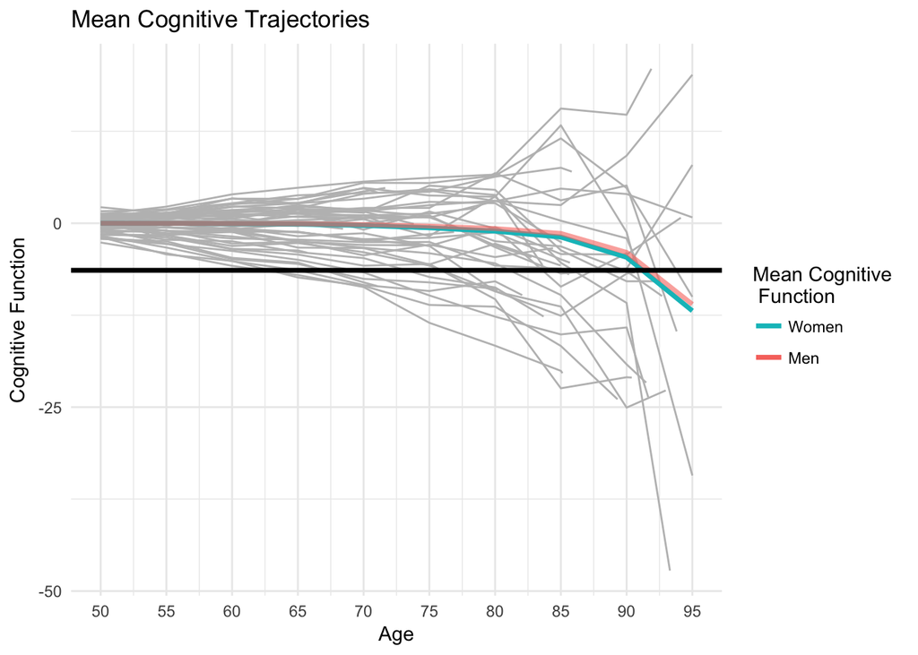

**These values will eventually just be tables in the parameters for the $C_{ij}$ model.**

Table 2.1: Observed mean slopes at each interval. Note that the mean slope (rate of cognitive change) becomes more negative with age.

| female | 50-55 | 55-60 | 60-65 | 65-70 | 70-75 | 75-80 | 80-85 | 85-90 | 90-95 |
| --- | --- | --- | --- | --- | --- | --- | --- | --- | --- |
| 0 | -0.003 | -0.006 | -0.007 | -0.022 | -0.040 | -0.067 | -0.133 | -0.515 | -1.41 |
| 1 | -0.004 | -0.008 | -0.014 | -0.035 | -0.063 | -0.092 | -0.161 | -0.551 | -1.46 |

Table 2.2: Variance of random slope for each interval (input parameters). Note that the variance of the random slope increases with age.

|  | 50-55 | 55-60 | 60-65 | 65-70 | 70-75 | 75-80 | 80-85 | 85-90 | 90-95 |
| --- | --- | --- | --- | --- | --- | --- | --- | --- | --- |
|  | 0.001 | 0.001 | 0.001 | 0.009 | 0.07 | 0.275 | 0.85 | 1.6 | 10 |

## 2.2 Dementia Cases

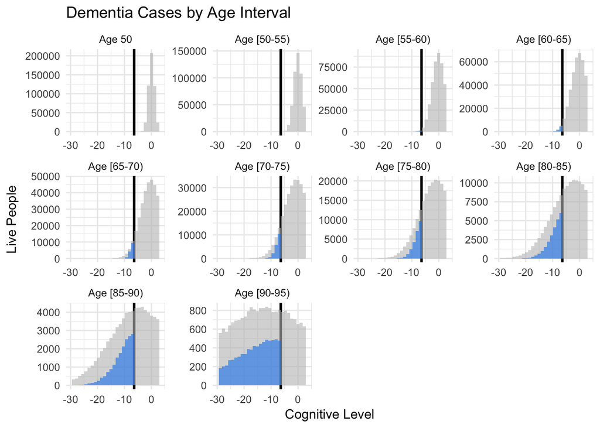

Figure 2.2: Dementia cases by age from one simulated sample. Incident cases at each age are plotted in blue. (Note that the y-axis differs across age bands because of the large difference in number of live people across age bins.)

Table 2.3: Prevalence of dementia by age for one simulated sample. Estimating this is not our primary goal, but we thought this might be another good sanity check. We expect that these numbers are higher than what they should be because in this scenario, dementia does not kill anyone.

|  | Age 50 | [50-55) | [55-60) | [60-65) | [65-70) | [70-75) | [75-80) | [80-85) | [85-90) | [90-95) |
| --- | --- | --- | --- | --- | --- | --- | --- | --- | --- | --- |
| Prevalence | 0 | 0 | 0.003 | 0.017 | 0.054 | 0.107 | 0.194 | 0.316 | 0.473 | 0.693 |

## 2.3 Distributions of U

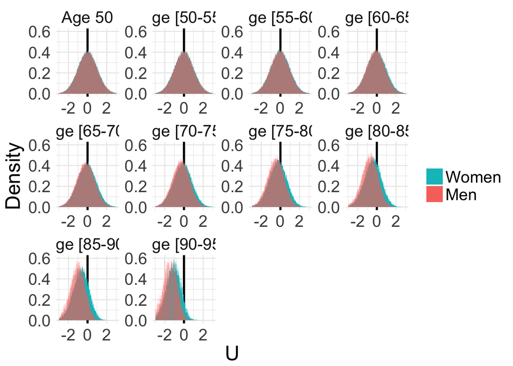

Figure 2.3: Distribution of U by age and sex/gender in one simulated sample.

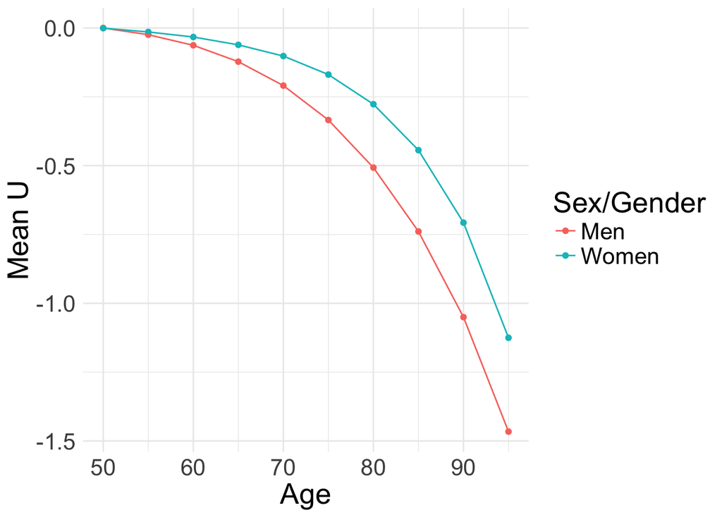

## 2.4 Extra Sanity Check Calculations

Table 2.4: Dementia-free person-years contributed to each 5-year age interval by sex from one simulated sample.

| Sex | Age [50-55) | [55-60) | [60-65) | [65-70) | [70-75) | [75-80) | [80-85) | [85-90) | [90-95) |
| --- | --- | --- | --- | --- | --- | --- | --- | --- | --- |
| Male | 1202878 | 1145987 | 1054627 | 915911 | 731451 | 515616 | 301784 | 133655 | 37477 |
| Female | 1263058 | 1231971 | 1179589 | 1089974 | 952916 | 760115 | 520952 | 278532 | 92594 |

|  | Age [50-55) | [55-60) | [60-65) | [65-70) | [70-75) | [75-80) | [80-85) | [85-90) | [90-95) |
| --- | --- | --- | --- | --- | --- | --- | --- | --- | --- |
| Female | 2 | 865 | 3461 | 8581 | 12206 | 17590 | 19503 | 16622 | 10435 |
| Male | 5 | 765 | 2953 | 7006 | 8701 | 11297 | 10445 | 7692 | 4193 |

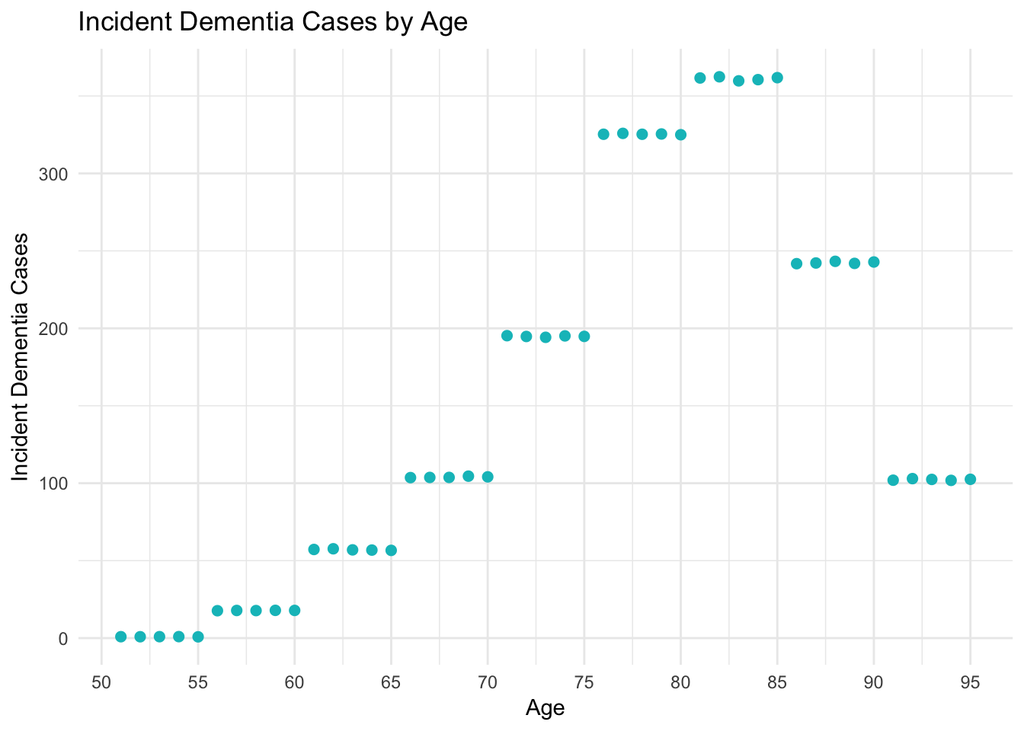

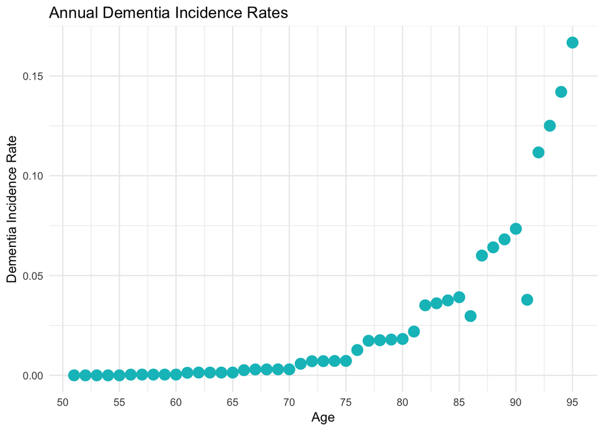

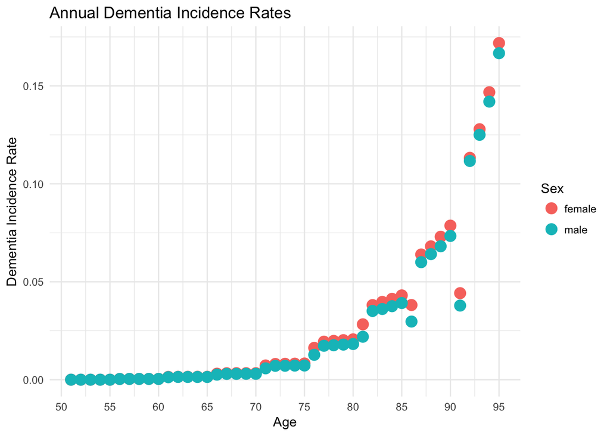

# References

[1] K. Andersen *et al.*, “Gender differences in the incidence of AD and vascular dementia: The EURODEM Studies. EURODEM Incidence Research Group,” *Neurology*, vol. 9, no. 53, pp. 1992–1997, 1999.

[2] R Core Team, “R: A language and environment for statistical computing.” R Foundation for Statistical Computing, Vienna, Austria, 2017 [Online]. Available: https://www.R-project.org/